# P.lagopus CpG NCBI

Andrés Delgado

2025-09-12

En este documento presento algunos resultados sobre los patrones de metilación de P.lagopus bajo distintos tratamientos de herbivoría.

## PREPROCESSING

#### Brevemente resumo los pasos previos al análisis:

1. Se utilizó como genoma de referencia el ensamblaje UofA_Burton_1 (Plantago ovata, GCA_028274465.1), descargado de NCBI Genome el [02/09/2025] en el siguiente enlace: https://www.ncbi.nlm.nih.gov/datasets/genome/GCA_028274465.1/
2. Alineamiento de las lecturas de bisulfito de mis muestras tratadas con el genoma de referencia usando BISMARK en linux.
3. Generación de informes de metilación de las muestras asociados a sus posiciones en el genoma de referencia. BISMARK genera estos informes en forma de archivos .bam
4. Importación de los archivos .bam a methylkit para el análisis

## CLUSTERING METHYLATION PROFILES

El primer paso en el análisis ha sido explorar visualmente las diferencias en los perfiles de metilación entre tratamientos. Para ello hemos utilizado los porcentajes de metilación de cada una de las posiciones CpG (3764 posiciones del genoma con una Citosina seguida de una Guanina) y los hemos comparado entre muestras para ver cuáles se parecen más entre sí y cuáles son más diferentes.Aquí muestro un Correlograma, un Dendograma y un DAPC (Discriminant Analysis of Principal Components), que es un análisis multivariante usado en genética de poblaciones para describir y visualizar la estructura genética entre grupos.Utiliza el PCA y luego maximiza la separación entre grupos predefinidos (los tratamientos).

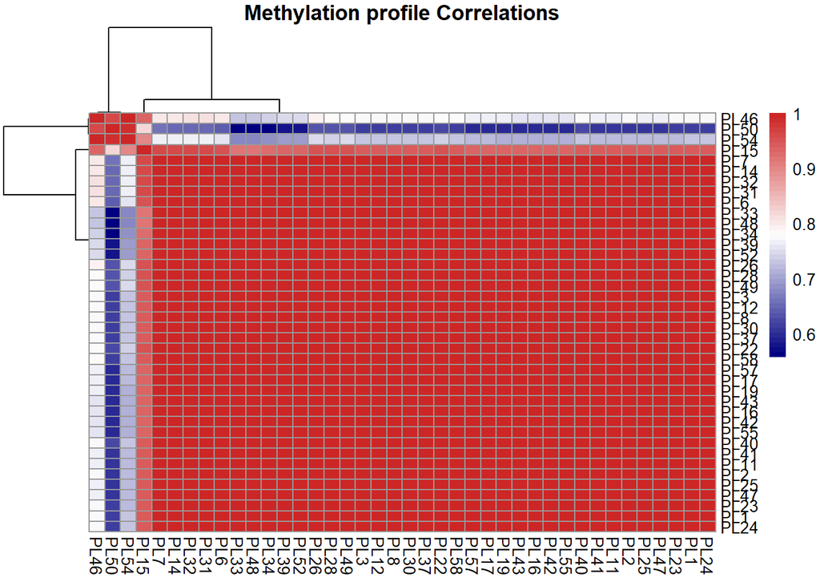

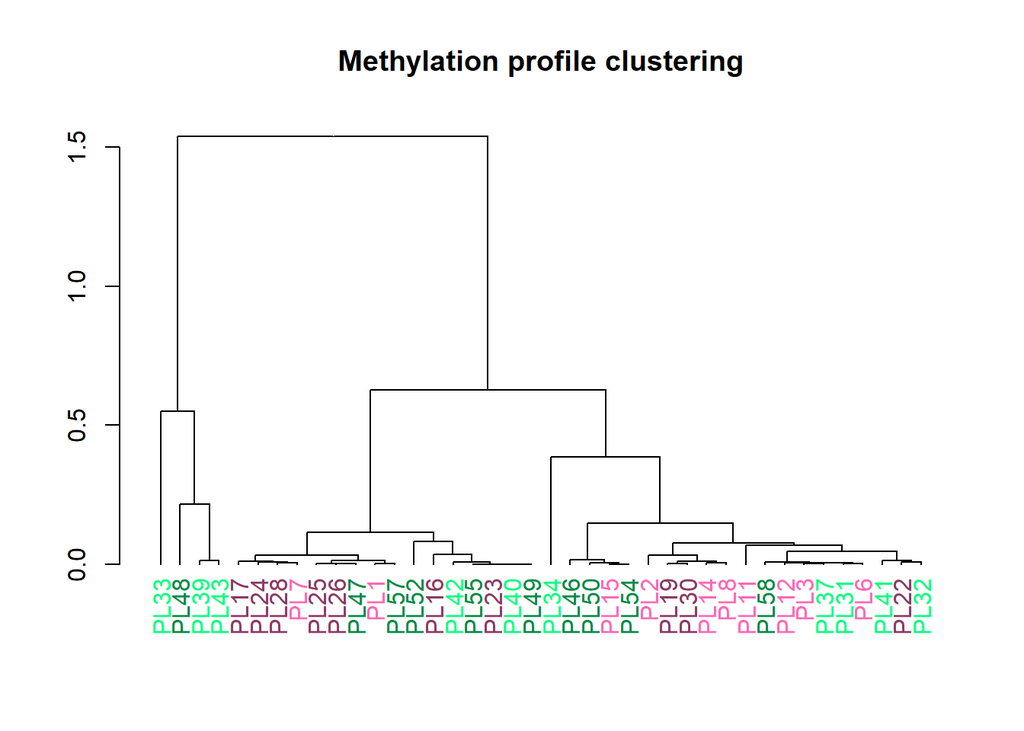

```
## Optimal number of PCs (alpha-score): 6
```

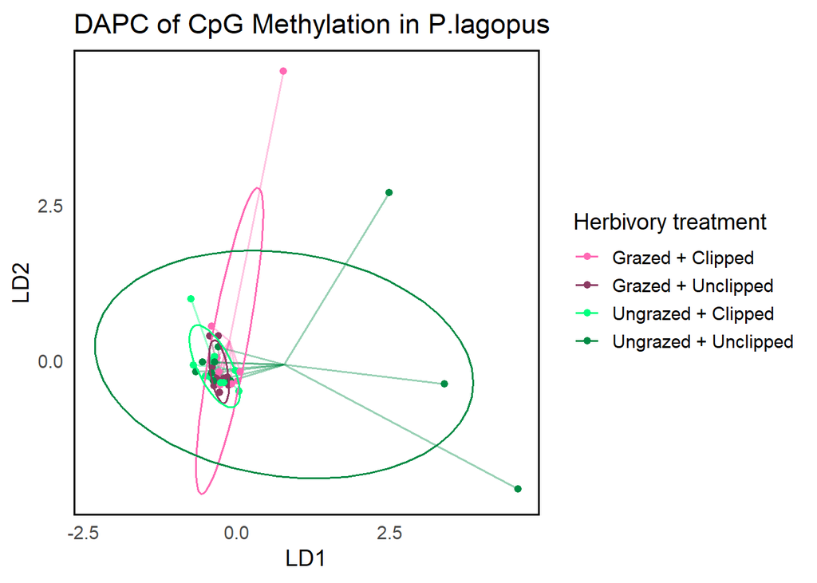

## IDENTIFYING IMPORTANT CpG SITES

Utilizando un Loading plot podemos visualizar cuáles son las posiciones CpG más importantes en la separación entre grupos en el eje LD1.

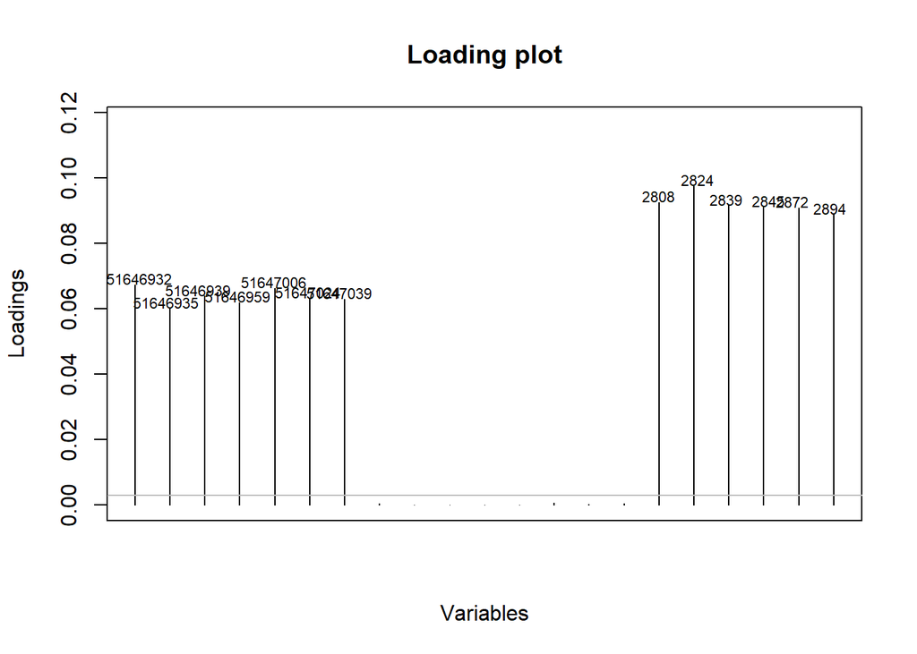

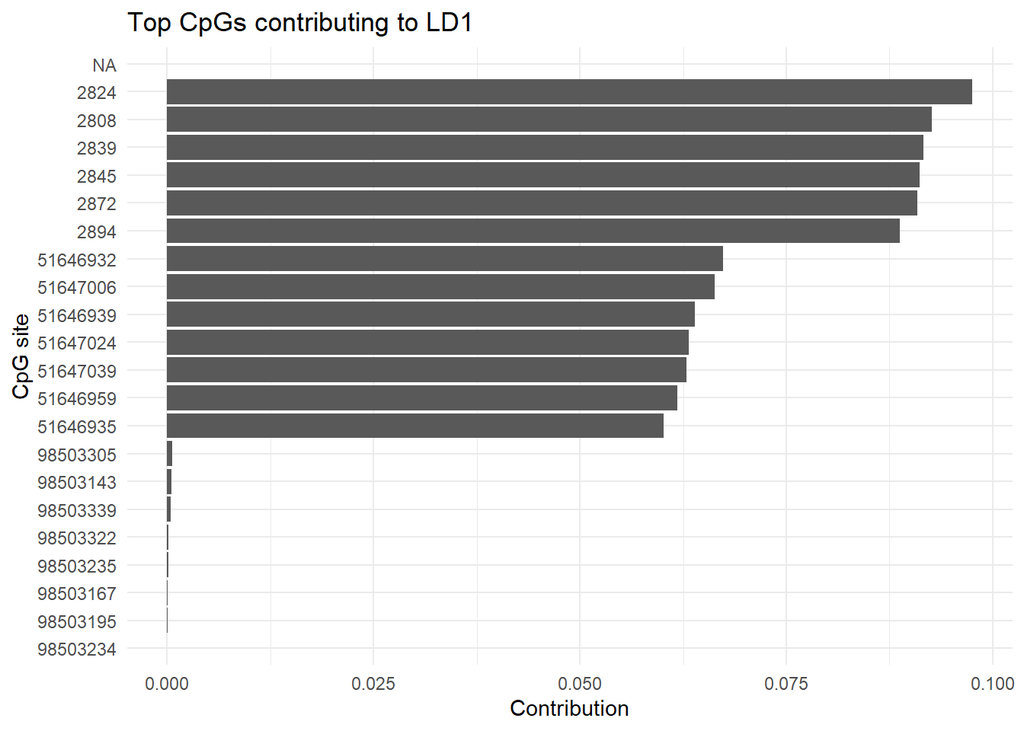

## HERBIVORY AND METHYLATION

Una vez hemos identificado los sitios de interés, podemos visualizar los porcentajes de metilación según tratamiento y ajustar modelos de regresión.

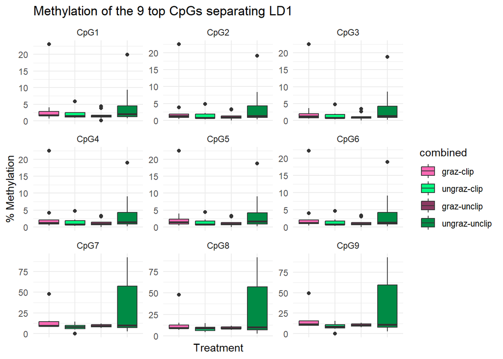

## BETA-BINOMIAL REGRESSION MODEL

Para evaluar el efecto individual e interactivo de los dos tratamientos sobre el porcentaje de metilación de cada CpG, utilizamos modelos de regresión con distribución beta-binomial.

Los porcentajes de metilación de cada CpG para cada muestra se calculan en base al conteo de citosinas metiladas y el conteo de citosinas sin metilar en ese sitio CpG.

Por ello, la distribución de nuestra variable respuesta tiene una distribución binomial. No obstante, las proporciones obtenidas tienen una variabilidad enorme y muchos 0s. Esto genera sobredispersión y los modelos con distribución binomial o quasibinomial no son buenos.

En cambio, la familia beta-binomial del paquete glmmTMB es la más adecuada para hacer regresiones con este tipo de datos.

**cbind(CpG1_Cs, CpG1_Ts) ~ simulation + maternal + simulation:maternal**  
CpG1 position = **2824**  
n = **40**

### CpG1 Post-hoc Comparisons with Tukeys HSD

| contrast | maternal | estimate | SE | df | z.ratio | p.value |
| --- | --- | --- | --- | --- | --- | --- |
| clip - unclip | graz | 0.35 | 0.36 | Inf | 0.97 | 0.334 |
| clip - unclip | ungraz | -0.31 | 0.34 | Inf | -0.91 | 0.365 |

| contrast | simulation | estimate | SE | df | z.ratio | p.value |
| --- | --- | --- | --- | --- | --- | --- |
| graz - ungraz | clip | 0.18 | 0.35 | Inf | 0.52 | 0.601 |
| graz - ungraz | unclip | -0.48 | 0.36 | Inf | -1.34 | 0.180 |

**cbind(CpG2_Cs, CpG2_Ts) ~ simulation + maternal + simulation:maternal**  
CpG2 position = **2808**  
n = **40**

### CpG2 Post-hoc Comparisons with Tukeys HSD

| contrast | maternal | estimate | SE | df | z.ratio | p.value |
| --- | --- | --- | --- | --- | --- | --- |
| clip - unclip | graz | 0.47 | 0.40 | Inf | 1.17 | 0.241 |
| clip - unclip | ungraz | -0.37 | 0.38 | Inf | -0.97 | 0.333 |

| contrast | simulation | estimate | SE | df | z.ratio | p.value |
| --- | --- | --- | --- | --- | --- | --- |
| graz - ungraz | clip | 0.27 | 0.38 | Inf | 0.71 | 0.477 |
| graz - ungraz | unclip | -0.56 | 0.40 | Inf | -1.42 | 0.156 |

**cbind(CpG3_Cs, CpG3_Ts) ~ simulation + maternal + simulation:maternal**  
CpG3 position = **2839**  
n = **40**

### CpG3 Post-hoc Comparisons with Tukeys HSD

| contrast | maternal | estimate | SE | df | z.ratio | p.value |
| --- | --- | --- | --- | --- | --- | --- |
| clip - unclip | graz | 0.47 | 0.40 | Inf | 1.17 | 0.242 |
| clip - unclip | ungraz | -0.39 | 0.38 | Inf | -1.03 | 0.305 |

| contrast | simulation | estimate | SE | df | z.ratio | p.value |
| --- | --- | --- | --- | --- | --- | --- |
| graz - ungraz | clip | 0.27 | 0.38 | Inf | 0.70 | 0.486 |
| graz - ungraz | unclip | -0.59 | 0.40 | Inf | -1.49 | 0.137 |

**cbind(CpG4_Cs, CpG4_Ts) ~ simulation + maternal + simulation:maternal**  
CpG4 position = **2845**  
n = **40**

### CpG4 Post-hoc Comparisons with Tukeys HSD

| contrast | maternal | estimate | SE | df | z.ratio | p.value |
| --- | --- | --- | --- | --- | --- | --- |
| clip - unclip | graz | 0.47 | 0.40 | Inf | 1.19 | 0.235 |
| clip - unclip | ungraz | -0.38 | 0.38 | Inf | -1.00 | 0.319 |

| contrast | simulation | estimate | SE | df | z.ratio | p.value |
| --- | --- | --- | --- | --- | --- | --- |
| graz - ungraz | clip | 0.28 | 0.38 | Inf | 0.75 | 0.456 |
| graz - ungraz | unclip | -0.56 | 0.40 | Inf | -1.43 | 0.153 |

**cbind(CpG5_Cs, CpG5_Ts) ~ simulation + maternal + simulation:maternal**  
CpG5 position = **2872**  
n = **40**

### CpG5 Post-hoc Comparisons with Tukeys HSD

| contrast | maternal | estimate | SE | df | z.ratio | p.value |
| --- | --- | --- | --- | --- | --- | --- |
| clip - unclip | graz | 0.49 | 0.40 | Inf | 1.23 | 0.217 |
| clip - unclip | ungraz | -0.40 | 0.38 | Inf | -1.07 | 0.285 |

| contrast | simulation | estimate | SE | df | z.ratio | p.value |
| --- | --- | --- | --- | --- | --- | --- |
| graz - ungraz | clip | 0.28 | 0.38 | Inf | 0.74 | 0.462 |
| graz - ungraz | unclip | -0.61 | 0.39 | Inf | -1.55 | 0.121 |

**cbind(CpG6_Cs, CpG6_Ts) ~ simulation + maternal + simulation:maternal**  
CpG6 position = **2894**  
n = **40**

### CpG6 Post-hoc Comparisons with Tukeys HSD

| contrast | maternal | estimate | SE | df | z.ratio | p.value |
| --- | --- | --- | --- | --- | --- | --- |
| clip - unclip | graz | 0.48 | 0.40 | Inf | 1.19 | 0.233 |
| clip - unclip | ungraz | -0.40 | 0.38 | Inf | -1.05 | 0.295 |

| contrast | simulation | estimate | SE | df | z.ratio | p.value |
| --- | --- | --- | --- | --- | --- | --- |
| graz - ungraz | clip | 0.29 | 0.38 | Inf | 0.76 | 0.448 |
| graz - ungraz | unclip | -0.58 | 0.40 | Inf | -1.47 | 0.142 |

**cbind(CpG7_Cs, CpG7_Ts) ~ simulation + maternal + simulation:maternal**  
CpG7 position = **51646932**  
n = **40**

### CpG7 Post-hoc Comparisons with Tukeys HSD

| contrast | maternal | estimate | SE | df | z.ratio | p.value |
| --- | --- | --- | --- | --- | --- | --- |
| clip - unclip | graz | 0.22 | 0.41 | Inf | 0.55 | 0.583 |
| clip - unclip | ungraz | -0.82 | 0.42 | Inf | -1.95 | 0.051 |

| contrast | simulation | estimate | SE | df | z.ratio | p.value |
| --- | --- | --- | --- | --- | --- | --- |
| graz - ungraz | clip | 0.39 | 0.42 | Inf | 0.93 | 0.354 |
| graz - ungraz | unclip | -0.65 | 0.40 | Inf | -1.61 | 0.108 |

**cbind(CpG8_Cs, CpG8_Ts) ~ simulation + maternal + simulation:maternal**  
CpG8 position = **51647006**  
n = **40**

### CpG8 Post-hoc Comparisons with Tukeys HSD

| contrast | maternal | estimate | SE | df | z.ratio | p.value |
| --- | --- | --- | --- | --- | --- | --- |
| clip - unclip | graz | 0.19 | 0.41 | Inf | 0.47 | 0.635 |
| clip - unclip | ungraz | -0.72 | 0.41 | Inf | -1.77 | 0.076 |

| contrast | simulation | estimate | SE | df | z.ratio | p.value |
| --- | --- | --- | --- | --- | --- | --- |
| graz - ungraz | clip | 0.24 | 0.41 | Inf | 0.59 | 0.553 |
| graz - ungraz | unclip | -0.67 | 0.40 | Inf | -1.67 | 0.095 |

**cbind(CpG9_Cs, CpG9_Ts) ~ simulation + maternal + simulation:maternal**  
CpG9 position = **51646939**  
n = **40**

### CpG9 Post-hoc Comparisons with Tukeys HSD

| contrast | maternal | estimate | SE | df | z.ratio | p.value |
| --- | --- | --- | --- | --- | --- | --- |
| clip - unclip | graz | 0.22 | 0.41 | Inf | 0.55 | 0.581 |
| clip - unclip | ungraz | -0.82 | 0.42 | Inf | -1.97 | 0.049 |

| contrast | simulation | estimate | SE | df | z.ratio | p.value |
| --- | --- | --- | --- | --- | --- | --- |
| graz - ungraz | clip | 0.40 | 0.42 | Inf | 0.95 | 0.341 |
| graz - ungraz | unclip | -0.65 | 0.40 | Inf | -1.60 | 0.109 |

## DIFFERENTIAL METHYLATION ANALYSIS

Con la función “pairwise_diff()” de methylKit, podemos comparar la población de cada tratamiento con la población control (en este caso el control es Grazed+Unclipped). Obtenemos hipo- e hiper- metilaciones con respecto al control, y cada una de estas diferencias está asociada a un p-valor. En este caso hemos considerado como Differentially Methylated Points (**DMPs**) cuando la **diferencia de metilación > 10%** y el **p-valor < 0.05**

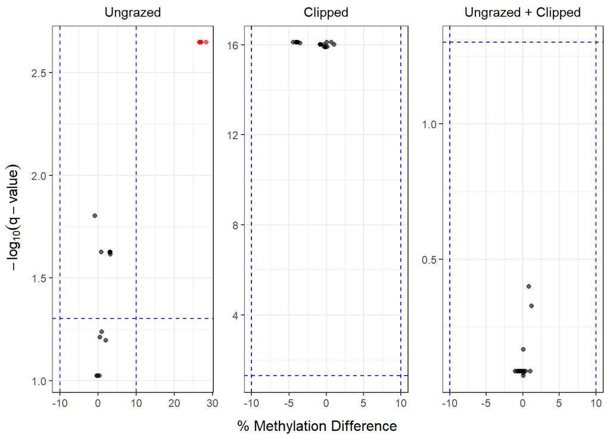

Differentially methylated sites

| Condition | Ungrazed | Clipped | Ungrazed…Clipped |
| --- | --- | --- | --- |
| Hypermethylated | 7 | 0 | 0 |
| Hypomethylated | 0 | 0 | 0 |